# Видеомониторинг-Соболевский-исходная

*ЗООЛОГИЧЕСКИЙ ЖУРНАЛ,*

*УДК 004.932.2*

**Методика зоологических исследований**

**Методология автоматизированного видеомониторинга арктической фауны с использованием интеллектуальной технологии AutoML**

Методология автоматизированного видеомониторинга арктической фауны с использованием интеллектуальной технологии AutoML

**© 2025 В. А. Соболевский*, В. В. Михайлов **,**

**Ф.Д. Гапоняко *****

*Федеральное государственное бюджетное учреждение науки “Санкт-Петербургский Федеральный исследовательский центр” РАН,*

*Санкт-Петербург, 199178 Россия*

**e-mail: arguzd@yandex.ru*

***e-mail: mwwcari@gmail.com*

***e-mail: *fedoraug@gmail.com*

В данной работе предложен подход к автоматизации мониторинга арктической фауны, призванный преодолеть ограничения традиционных, трудоёмких и финансово весьма затратных в обширных и труднодоступных полярных регионах. Технологической основой служит интеграция модели распознавания объектов фауны на изображениях с видеозаписями, полученными с беспилотных летательных аппаратов (БПЛА). Эффективность данного подхода была оценена на основе экспериментов с видеозаписями северных оленей, овцебыков и казарок в различных условиях съёмки. Анализ позволил выявить два ключевых фактора, влияющих на точность распознавания объектов: динамику камеры БПЛА и взаимные перекрытия животных в плотных группах. Было показано, что движение камеры может привести к повторной идентификации алгоритма отслеживания, в то время как окклюзии приводят к потере и подмене идентификаторов у визуально схожих особей. Однако, описанные ограничения, вызванные факторами съёмки, нивелируются использованием методологии видеосъёмки, в частности съёмкой в надир.

На основе этих выводов в статье обосновывается, применение AutoML-платформы AutoGenNet. Подобный подход позволяет экологам и специалистам в предметной области самостоятельно и оперативно создавать высокоточные модели для конкретных видов и условий, не требуя глубоких познаний в машинном обучении, что открывает путь к широкому внедрению видеомониторинга в природоохранную практику.

*Ключевые слова:* видеомониторинг, YOLO, автоматизированное машинное обучение, DeepSort, арктическая фауна, беспилотные летательные аппараты.

Эффективное управление и сохранение популяций животных Арктики (как имеющих статус краснокнижных, так и массовых промысловых) в условиях быстро меняющийся среды и растущей антропогенной нагрузки требует оперативного сбора точных данных об их численности и структуре (Efremov et al., 2024; Cuyler et al., 2020). Традиционные методы учета, основанные на ручной обработке материалов фото или видеосъёмки, имеют существенные ограничения в части масштабируемости и скорости, что делает невозможным своевременное реагирование на изменения (Hodgson et al., 2016; Бондарь, Колпащиков, 2018). В связи с этим разработка программно-аппаратных комплексов для автоматизированного сбора и анализа визуальных данных представляет собой актуальное и практически важное направление исследований. Сложности, обусловленные огромными и труднодоступными территориями, а также суровыми погодными условиями, подчеркивают необходимость в создании автоматизированных решений (Lee et al., 2019).

Объектами в данном исследовании являются три вида – северный олень, овцебык и казарка. Мониторинг этих животных особенно актуален, так как некоторые их популяции имеют охранный статус или занесены в Красную книгу, что требует повышенного внимания к ним. Для массовых охотничье-промысловых популяций автоматизированные системы мониторинга не менее важны, поскольку дают возможность регулярно и оперативно оценивать состояние популяций и устанавливать промысловые квоты.

В домашнем оленеводстве автоматизированный мониторинг на базе БПЛА может использоваться для решения сходных задач, а также для оценки физиологического состояния оленей в стадах и выявления заболевших. При этом обучающая выборка должна включать изображения оленей разной степени упитанности и животных с визуальными признаками заболеваний.

Автоматизация учета животных представляет собой актуальную задачу, решение которой возможно посредством применения беспилотных летательных аппаратов (БПЛА) и методов компьютерного зрения (Wang et al., 2023; Chen et al., 2024). Такие методы обеспечивают анализ визуальной информации, поступающей с камер БПЛА, и позволяют реализовать эффективные системы мониторинга (Weber et al., 2023). Структурно такие системы включают два ключевых компонента: модуль распознавания (детектирования) и модуль многообъектного анализа траекторий (MOT) на видео (Cao et al., 2024).

В качестве основы для реализации модуля распознавания (детектора) в настоящем исследовании выбрана архитектура сверточной нейронной сети (СНС) YOLO (Redmon et al., 2016), демонстрирующая высокую скорость обработки при сохранении высокой точности распознавания. Для реализации модуля отслеживания объектов на видео используется алгоритм DeepSort (Wojke et al., 2017). Он основан на парадигме отслеживания по результатам распознавания (Luo et al., 2021), что позволяет достигать устойчивого качества отслеживания животных на видео в условиях сложной визуальной сцены. Интеграция данных технологий осуществлялась на базе программного комплекса AutoGenNet (Соболевский и др., 2024; Sobolevskii, 2025), предназначенного для автоматизированного машинного обучения (AutoML) и обеспечивающего автоматизированную генерацию моделей и сопутствующих программных оболочек. Ранее данная технология была применена нами в системе распознавания и подсчета северных оленей и черных казарок на аэрофотоснимках (Соболевский и др., 2025). В представленной статье работа над системой была продолжена. Ниже описаны модификации, которые были добавлены в AutoGenNet для расширения её функциональности и возможности работы с видеофрагментами.

Объекты мониторинга и исходные данные

В качестве объектов распознавания взяты три типичных арктических вида – таймырский дикий северный олень тундрового подвида (Rangifer tarandus taimyrensis), черная казарка номинативного (Branta bernicla bernicla) и тихоокеанского (Branta bernicla) подвидов, а также овцебык (Ovibos moschatus). Для обучения и тестирования моделей использовались данные, выложенные в открытый доступ и полученные с использованием БПЛА.

Северные олени

Дикий северный олень является ключевым объектом государственного мониторинга в российской Арктике в силу его роли как фонового вида полярных экосистем. Статус этого вида крайне неоднозначен: многие популяции, в том числе в европейской части России, а также гыданская и камчатская, занесены в федеральные или региональные Красные книги. В то же время другие, например, популяции Таймыра, Якутии и Чукотки, продолжают оставаться объектом охоты, несмотря на зафиксированное резкое падение их численности.

Для эффективного управления популяциями, будь то разработка мер охраны или определение квот на добычу, необходимы точные данные об их численности и половозрастной структуре. Существующая методика учёта основана на уникальной поведенческой адаптации тундровых оленей: в летний период, спасаясь от массового вылета кровососущих насекомых, они формируют многотысячные скопления (Зырянов и др., 1971). Открытые ландшафты тундры и контрастная окраска животных позволяют эффективно обнаруживать эти скопления с воздуха. Учётные работы проводятся с малых самолётов, с которых производится полная аэрофотосъёмка стад. После этого специалисты вручную подсчитывают количество особей на тысячах полученных изображений, что позволяет учесть до 80% популяции. Оставшаяся часть оценивается методом территориальной аппроксимации (Колпащиков и др., 1999, 2008; Челинцев, 2000; Бондарь, Колпащиков, 2018).

Масштаб этой задачи огромен, что наглядно демонстрируют данные с полуострова Таймыр. В ходе авиаучётов, проводившихся здесь 24 раза с 1966 по 2022 год, были зафиксированы стада численностью до 300 000 особей (Якушкин и др., 2001). На одном фотоснимке могло находиться до 35 000 животных (Бондарь, Колпащиков, 2018). Таким образом, один полевой сезон генерирует архив из нескольких тысяч изображений, ручная обработка которого является чрезвычайно трудоёмкой и длительной задачей.

Овцебыки

Последняя в Евразии таймырская популяция овцебыков вымерла около 3 тыс. лет назад в результате потепления климата. Интродукция овцебыка на Севере Сибири была проведена в 1974-1975 гг., когда с острова Банкс (Канада) и Нунивак (США) на Таймыр и на остров Врангеля было завезено 50 овцебыков (Якушкин, 1998). Этот вид в настоящее время образует несколько стабильных популяций, в том числе на Таймыре, острове Врангеля и в Якутии. Ряд популяций имеет особый охранный статус и занесён в региональную Красную книгу (Красная книга Республики Саха, 2003), что делает задачу точного мониторинга их состояния особенно важной для оценки успеха программ по восстановлению вида и его дальнейшего сохранения.

Ключевой особенностью поведения овцебыков, которая лежит в основе методик их учёта, является их защитная реакция – при угрозе животные сбиваются в плотную группу, часто образуя круговое каре (Якушкин, 1998). Такое поведение делает стадо хорошо заметным на открытых пространствах тундры, особенно в зимний период на фоне снега. Крупные размеры и тёмная окраска животных обеспечивают высокий контраст, что способствует их успешному обнаружению с воздуха.

Казарки

Казарки представляют собой группу арктических гусей, тесно связанных с морскими побережьями (Гаврило, 2023). Гнездование в условиях сурового климата высоких широт приводит к значительным ежегодным колебаниям успеха размножения и, как следствие, численности. Особый интерес для мониторинга представляет тихоокеанская чёрная казарка, гнездящаяся на арктических островах и в тундровой зоне азиатской части России. Этот подвид образует крупные скопления в местах гнездования и на линных концентрациях, что делает его удобным объектом для проведения авиаучётов.

Благодаря однородной тёмной окраске, отличающей их от других видов гусей (Сыроечковский, 2011), и отсутствию выраженного полового диморфизма, казарки являются хорошим объектом для разработки методов автоматического распознавания на фотографиях. Авиаучёт казарок в России имеет относительно недавнюю историю, и его методология (Розенфельд и др., 2017) во многом схожа с методикой учёта других стадных животных, описанной выше.

Особенности объектов распознавания

При анализе видеоматериалов с животными модель автоматического отслеживания сталкиваются с рядом общих трудностей. К ним относятся переменчивые условия освещения, наличие фоновых объектов, создающих визуальный шум, и изменение видимого масштаба животных в зависимости от расстояния (Liu et al., 2024; Fazzari et al., 2025). Ключевой общей проблемой для отслеживания животных на видео является возникновение частых наложений изображений животных друг на друга в плотных группах (окклюзий), из-за которых алгоритму необходимо корректно обрабатывать временное исчезновение и повторное появление особей, не теряя их траектории.

Фундаментальное различие между задачами отслеживания этих видов заключается в размерности пространства, в котором они преимущественно перемещаются. Движение овцебыков и оленей происходит в условно двумерном пространстве по поверхности земли и воды. Это делает их траектории более предсказуемыми с точки зрения кинематики. Казарки же способны перемещаться в трёхмерном пространстве, используя сушу, воду и воздух. Сценарии с полётом представляют собой отдельную и значительно более сложную задачу отслеживания.

Это различие напрямую влияет на сложность задач для алгоритмов отслеживания. В случае летящих птиц контуры и внешний вид объекта кардинально меняются от кадра к кадру из-за взмахов крыльев. В результате, разработка универсальной модели отслеживания казарок во всех средах на видео является на порядок более сложной задачей, чем для овцебыков.

Стоит отметить, что видеоматериалы, использованные в данном исследовании, отражают лишь часть из описанных проблем, позволяя сфокусироваться на конкретных, но важных сценариях. Так, для овцебыков и северных оленей был проанализирован случай с динамичной камерой (облёт стада с БПЛА), а для казарок — сценарий со стационарной камерой, но сложной динамической сценой (птицы на воде). При этом наиболее сложный сценарий, заключающийся в отслеживании летящих птиц, не входил в рамки текущей работы.

Методы

**Архитектура системы автоматизированного видеомониторинга**

Применение БПЛА, оснащённых видеокамерами, для мониторинга диких животных является адаптацией подхода, уже доказавшего свою состоятельность в задачах мониторинга широкого спектра сложных экосистем (Buchelt et al., 2024; Pedrazzi et al., 2025). В лесных массивах, где плотный полог и пересечённая местность создают высокий уровень визуальной окклюзии, БПЛА успешно применяются для учёта численности скрытных видов (Haitao et al., 2024; Pagacz S., Witczuk J., 2023). В условиях же открытых ландшафтов, технология решает другую ключевую задачу эффективного обследования обширных территорий для обнаружения стадных животных на камуфлирующем фоне. Методика комбинированного использования БПЛА и методов компьютерного зрения может быть адаптирована к разработке методов мониторинга арктических природных комплексов и популяций животных с учетом как сходства, так и различия объектов и условий распознавания в различных природно-климатических эонах.

Анализ видеоданных, полученных с БПЛА в условиях открытой местности, сопряжён с рядом технических сложностей. К числу основных факторов, затрудняющих обработку изображений, относятся: нестабильность фона, вариативность природного освещения, визуальные перекрытия объектов внутри групп животных, а также подвижность камеры, обусловленная спецификой видеосъёмки. В контексте мониторинга животных на основе видеоданных ключевым элементом современных аналитических систем выступает технология MOT. Данная технология реализует не само распознавание объектов на отдельных кадрах, а их сопряжение на временной шкале между различными кадрами путём назначения уникальных идентификаторов и отслеживания соответствующих траекторий в течение всей видеопоследовательности. Это позволяет проводить индивидуальный учёт животных с минимизацией количества случаев повторного счёта, отслеживать структуру миграционных потоков, анализировать поведенческую активность, социальную иерархию внутри групп, а также выявлять нетипичные поведенческие реакции, потенциально связанные с физиологическим стрессом или заболеваниями (Jagielski et al., 2022; Nidhi et al., 2025; Han et al., 2023).

Функциональная основа таких систем строится на результатах использовании СНС, обеспечивающих автоматическое извлечение признаков и высокую адаптивность к условиям наблюдения. Среди различных архитектур особое место занимает YOLO, в частности её последняя модификация YOLOv11 (Redmon et al., 2016), которая демонстрирует оптимальный баланс между вычислительной эффективностью и качеством распознавания (Hu et al., 2025; Nan et al., 2025). Благодаря способности обрабатывать изображения с высокой частотой и устойчиво выделять объекты различных масштабов, включая случаи частичных окклюзий, данная архитектура широко применяется в задачах наблюдения за дикой природой (Chen et al., 2024).

Однако, несмотря на высокую эффективность в локализации объектов, архитектура YOLO не предназначена для самостоятельного решения задачи отслеживания объектов. Её выходные данные ограничиваются координатами обнаруженных объектов и их классами на каждом отдельном кадре, без сохранения межкадровой связности. В частности, YOLO не предусматривает механизмов сопоставления объектов между последовательностями, управления идентификаторами или восстановления соответствий после временных потерь видимости – механизмов повторной идентификации (Re-Identification, re-ID).

Для избавления от этих ограничений используется парадигма отслеживания по результатам распознавания, в рамках которой данные от независимого детектора поступают на вход специализированному алгоритму отслеживания. Уже этот алгоритм выполняет ассоциацию обнаруженных объектов с ранее зафиксированными траекториями, обеспечивая непрерывность наблюдения. Среди широкого спектра таких алгоритмов отслеживания, совместимых с архитектурами семейства YOLO, алгоритм DeepSort (Wojke et al., 2017) был выбран в настоящем исследовании как наиболее устойчивый к визуальным и динамическим искажениям, характерным для полевых условий и видеосъёмки.

Алгоритм DeepSort сочетает предсказание движения, основанное на фильтре Калмана, с компонентой визуального соответствия, реализуемой через re-ID. Последние формируют компактные векторные дескрипторы, отображающие индивидуальные особенности внешнего вида объекта. Применение таких дескрипторов позволяет корректно восстанавливать идентичность объектов даже после их длительных отсутствия (к примеру, выход из поля зрения камеры), что критически важно для задач видеонаблюдения в условиях частых перекрытий, низкой плотности кадров и перемещений камеры, типичных для БПЛА.

Таким образом, комбинация архитектуры распознавания объектов YOLOv11 и алгоритма отслеживания DeepSort позволяет реализовать устойчивую систему мониторинга (Ngeni et al., 2024), способную обеспечивать высокую достоверность анализа в сложных условиях.

Методология автоматизированного синтеза систем видеомониторинга

Существующие научные работы и программные решения демонстрируют большие потенциальные возможности систем автоматизированного видеомониторинга животных, построенных на интеграции СНС и алгоритма МОТ (Weber et al., 2023; Ngeni et al., 2024). Однако адаптация такой системы под каждую новую прикладную задачу, такую как мониторинг нового вида животных или работа в других географических условиях, остаётся ресурсоёмкой задачей, требующей значительных временных затрат и привлечения специалистов в области машинного обучения. Чтобы сократить эти издержки и ускорить практическое внедрение таких технологий, была разработана методология, нацеленная на автоматизированный синтез систем видеомониторинга.

Инструментальной основой для автоматизированного создания моделей распознавания выступает программный комплекс AutoGenNet. Он базируется на концепции автоматизированного машинного обучения (Automated Machine Learning, AutoML), что позволяет значительно ускорить процесс разработки и уменьшить зависимость от ручной работы специалистов по машинному обучению. На рис. 1 представлена общая схема предлагаемой методологии, включающей использование программного комплекса AutoGenNet.

Рис.1

В программном комплексе AutoGenNet уже реализованы алгоритмы для полностью автоматизированного синтеза моделей YOLO и генерации программных оболочек для них. Принципиально важно, что в рамках предложенной методологии алгоритм отслеживания объектов является универсальным модулем и не требует модификации для разных задач. Таким образом, вся адаптация системы к мониторингу нового вида сводится к автоматизированному обучению детектора YOLO на размеченных изображениях животных этого вида, в то время как последующая обработка видеопотока для отслеживания происходит унифицировано.

Комбинация представленных на схеме алгоритмов и программных средств автоматизированного синтеза моделей машинного обучения в единую методологию позволяет достичь поставленной цели. Их совместное использование даёт возможность исключить из процесса создания как моделей машинного обучения для распознавания и отслеживания животных на видео, так и программных оболочек этих моделей для интеграции их в новые системы видеомониторинга этап ручной разработки и настройки моделей со стороны специалистов по машинному обучению. Это, в свою очередь, кардинально снижает затраты ресурсов и времени, тем самым упрощая и ускоряя внедрение технологий машинного обучения в практику экологического мониторинга.

Результаты

Для тестирования представленной методологии автоматизированного видеомониторинга арктической фауны были использованы видеофрагменты, представляющие собой разные сценарии мониторинга с использованием БПЛА.

Наблюдение за северными оленями и овцебыками осуществлялось в естественной среде обитания при дневном освещении с применением БПЛА. Видеоматериалы, полученные в результате съёмки, характеризуется рядом особенностей, создающих значительные трудности для систем отслеживания: перемещение камеры, во время полёта, приводило к постоянному изменению фона и угла обзора; в плотной группе животных часто происходили частичные взаимные перекрытия; высокая степень визуального сходства между особями усложняла задачу повторной идентификации. Видеоматериалы были выбраны для анализа в силу своей репрезентативности. Они содержат типичный набор факторов, ограничивающих точность и устойчивость автоматических систем отслеживания.

Видеозапись с казарками была получена с использованием стационарной камеры, фиксированной на берегу водоёма и направленной на открытую водную поверхность. Хотя в данном сценарии отсутствовало движение камеры, основные сложности были связаны с оптическими искажениями: блики от солнечного света, отражения на поверхности воды и рябь, вызванная ветром, формировали визуальные артефакты, нарушающие целостность контуров объектов и создающие шум как для алгоритма распознавания, так и для алгоритма отслеживания.

С целью оценки качества отслеживания при тестировании методологии были использованы четыре основных типа ошибок подсчета оленей, отражающие характерные сбои, возникающие при видеомониторинге животных в условиях сложной визуальной сцены:

- Дублирование отслеживания объекта (ДО) – тип ошибки, возникающей в случае многократного подсчета одного и того же объекта.
- Ошибочная классификация объекта (ОК) – тип ошибки, возникающей, когда алгоритм распознаёт объект, не являющийся целевым (например, животное другого вида).
- Повторная инициализация после окклюзии (ПИПО) – тип ошибки, возникающей при повторном распознавании объекта после периода частичной или полной окклюзии другим объектом.
- Повторная инициализация после выхода из кадра (ПИПВ) – аналогична ПИПО, но регистрируется для случаев, когда объект полностью покидает поле зрения камеры на некоторый промежуток времени.

Суммарные данные по количеству ошибок каждого типа для всех видов животных представлены в таблице.

Таблица

Северные олени

Для анализа использовался видеофрагмент с пролётом БПЛА над стадом северных оленей. В качестве детектора применялась стандартная модель YOLO, изначально обученная на наборе данных MS COCO.

Данные из таблицы показывают умеренное общее количество ошибок (14) для 67 особей на всём видео. Основной вклад в погрешность внесло дублирование отслеживания объекта (ДО = 10). Причиной этого является динамика пролёта БПЛА. По мере движения камеры расстояние до оленей и, соответственно, их видимый масштаб на кадре непрерывно менялись. В моменты, когда масштаб изменялся слишком резко, или когда ракурс животного значительно отличался от предыдущего кадра, механизм re-ID в DeepSort мог кратковременно потерять объект. При немедленном повторном обнаружении алгоритм отслеживания присваивал ему новый ID, что и регистрировалось как ошибка дублирования.

Крайне низкое количество ошибок повторной инициализации после окклюзии (ПИПО = 3) полностью соответствует условиям эксперимента. Так как стадо было разреженным, физические перекрытия животных практически отсутствовали. Три случая ошибок были вызваны не системными окклюзиями, а кратковременными сбоями самого детектора, когда он на несколько кадров терял одного из животных. Единичная ошибка классификации (ОК = 1) появилась в результате смещения алгоритма отслеживания траектории с одного оленя на другого. Нулевое значение ошибок ПИПВ объясняется тем, что в ходе пролёта олени не возвращались в поле зрения камеры.

Рисунок 2 демонстрирует, что в отсутствие окклюзий основной проблемой для алгоритма DeepSort становится неспособность его re-ID компонента справляться с быстрыми изменениями масштаба и ракурса объектов, вызванными движением БПЛА.

Рис.2

Овцебыки

Для анализа использовался видеофрагмент, на котором БПЛА совершает облёт стада овцебыков по круговой траектории. В данном случае также применялась стандартная модель YOLO, изначально обученная на наборе данных MS COCO.

При использовании модели не возникло ситуаций ошибочной классификации животных (ОК = 0). Детектор был достаточно робастным, чтобы не путать овцебыков с нерелевантными объектами, а так как в сцене не было других видов животных, ложные срабатывания детектора на другие классы были исключены. Таким образом, основной вызов для системы заключался не в обнаружении как таковом, а в задаче стабильного отслеживания.

Как видно из таблицы, подавляющее большинство ошибок пришлось на ДО = 40 и ПИПО = 17. Основной причиной такого большого количества ошибок является именно динамика камеры БПЛА, непрерывно облетающего стадо. Движение по кругу приводит к постоянному и значительному изменению ракурса, с которого камера видит каждое животное. Компонент re-ID в алгоритме DeepSort, который опирается на визуальные признаки объекта, крайне чувствителен к таким изменениям. Когда внешний вид овцебыка на кадре кардинально меняется, алгоритм больше не может сопоставить его с уже существующей траекторией. В результате алгоритм отслеживания ошибочно прерывает отслеживания старой траектории и инициирует отслеживание новой с другим ID, что и приводит к накоплению ошибок ПИПО и ДО.

На Рис. 3 продемонстрирован тип видеосъёмки овцебыков.

**Казарки**

Рис.3

Аналогично сценарию с овцебыками, для отслеживания казарок использовалась стандартная модель детектора YOLO, предварительно обученная на наборе данных MS COCO. Ключевым отличием экспериментальных условий была стационарная камера, что и является главной причиной более низкого общего числа ошибок (всего 13).

Отсутствие движения камеры полностью устранило основную проблему, наблюдавшуюся при отслеживании овцебыков – постоянное изменение ракурса. Стабильность ракурса птиц относительно камеры позволило алгоритму отслеживания работать значительно надежнее.

Основной вклад в погрешность внесли ошибки ПИПО = 9. В данном случае ошибки были вызваны зачастую взаимными перекрытиями птиц. Когда одна казарка проплывала за другой, даже на короткое время, алгоритм отслеживания терял её из виду. После того как птица снова появлялась, механизм re-ID в DeepSort не мог надежно сопоставить её с прерванной траекторией. Это происходило потому, что универсальный детектор воспринимает всех казарок как визуально практически идентичные объекты. Не имея уникальных внешних признаков для каждой особи, алгоритм re-ID не мог разрешить неоднозначность и, как следствие, присваивал птице новый ID, считая её новым объектом.

Это классический пример сбоя re-ID при работе с плотными группами визуально однородных объектов. Остальные ошибки были единичными. Три случая ДО и одна ОК были, вызваны случайными и кратковременными сбоями детектора, а не системной проблемой.

Рис. 4

На рис. 4 показан вид съёмки казарок. Результаты для казарок демонстрируют, что при устранении фактора движения камеры, точность отслеживания резко возрастает. Проблема смещается с неспособности алгоритма отслеживания обрабатывать смену ракурса на его неспособность различать внешне одинаковые объекты после того, как они перекрывают друг друга.

Обсуждение

В этом контексте особенно показательны результаты для северных оленей. В данном сценарии, также с движущейся камерой БПЛА, но в отсутствие значительных окклюзий, общее количество ошибок составило всего 14. Это доказывает, что именно комбинация движения камеры и плотных перекрытий приводит к лавинообразному росту ошибок, как в случае с овцебыками. Умеренное число ошибок у оленей, преимущественно дублирование отслеживания (ДО = 10), показывает, что при изменении масштаба и ракурса всё же происходят кратковременные сбои ассоциации. Однако, поскольку объект не перекрывается другим, детектор немедленно обнаруживает его снова и тут же присваивает ему новый ID. Таким образом, сценарий с оленями позволил изолировать и количественно оценить влияние именно динамики камеры на работу алгоритма отслеживания.

Напротив, в сценарии с казарками, где камера была неподвижна, алгоритм отслеживания продемонстрировал ожидаемо высокую стабильность. Низкое общее число ошибок показывает, что при постоянном ракурсе DeepSort успешно справляется с задачей. Оставшиеся ошибки, в основном ПИПО, указывают на другую фундаментальную проблему – отслеживание визуально идентичных объектов. Когда одна казарка перекрывала другую, универсальный детектор не мог предоставить никаких уникальных признаков, чтобы различить их после разделения. В результате алгоритм отслеживания присваивал одной из птиц новый ID. Это демонстрирует предел возможностей данного подхода при работе с плотными группами однородных объектов, даже в идеальных условиях съемки.

Подводя итог тестирования, можно сказать, что выявленные ограничения по большей части связаны со спецификой съёмки, которую довольно легко устранить. Ведение съёмки в надир позволит избежать большого числа возможных ошибок и эффективно использовать предложенные алгоритмы.

Интеграция архитектуры YOLOv11 в программную платформу AutoGenNet обеспечила возможность автоматизированного построения моделей компьютерного зрения с применением методов AutoML. В рамках данной платформы реализован целый ряд функций, включая автоматический структурно-параметрический синтез моделей, оптимизацию гиперпараметров, а также адаптивный выбор метрик оценки качества. Центральным компонентом реализации этих функций выступает модифицированный генетический алгоритм, адаптированный к специфике задач построения моделей глубокого обучения.

С точки зрения задач, решаемых в рамках данного исследования, следует отметить, что система AutoGenNet предоставляет не только средства для автоматической генерации моделей распознавания, но и инфраструктуру для интеграции алгоритмов отслеживания, таких как DeepSORT. Этот алгоритм включен в состав программной оболочки, генерируемой платформой, что позволяет в автоматическом режиме строить связки из алгоритмов распознавания и отслеживания, без необходимости ручного конфигурирования и кодирования.

Таким образом, в рамках предложенной методологии AutoGenNet выступает как универсальная платформа для комплексной автоматизации процессов разработки систем видеомониторинга. Применение подходов автоматизированного машинного обучения в задачах наблюдения за животными в естественной среде позволяет существенно снизить порог входа в разработку таких систем, а также минимизировать временные и вычислительные затраты. Более того, модульная архитектура платформы обеспечивает её расширяемость: она позволяет интегрировать как новые архитектуры нейросетей для распознавания, так и алгоритмы отслеживания, ориентированные на различные типы сцен и объектов. Это делает AutoGenNet перспективным инструментом для масштабируемого и воспроизводимого создания решений в области цифрового животноводства и экологического мониторинга.

Заключение

В настоящей работе была проведена оценка эффективности методологии автоматизированного видеомониторинга арктической фауны, базирующейся на использовании детектора YOLO и алгоритма отслеживания DeepSort, в рамках программного комплекса AutoGenNet, применительно к задачам мониторинга арктических животных. Целью исследования было выявить ключевые факторы, влияющие на качество мониторинга, и определить ограничения такого подхода.

Экспериментальный анализ проводился на трёх принципиально разных видеоматериалах: съёмке овцебыков и северных оленей с динамичной камеры БПЛА и съёмке казарок со стационарной камеры. Полученные результаты однозначно продемонстрировали, что условия съёмки являются доминирующим фактором, определяющим эффективность применения методологии. Наибольшее количество ошибок было зафиксировано в сценарии с овцебыками, где на 36 отслеживаемых особей пришлось более полутора ошибок на каждую. К такому неудовлетворительному результату привело одновременное действие двух негативных факторов: постоянной смены ракурса из-за движения БПЛА и плотных взаимных перекрытий в стаде. Это сочетание представляет собой наихудший сценарий для системы.

Несколько лучшие результаты система показала в эксперименте с казарками. Использование стационарной камеры устранило проблему смены ракурса, но 13 ошибок на 12 отслеживаемых птиц свидетельствуют о фундаментальной слабости подхода. Причиной стали взаимные окклюзии. Не имея уникальных визуальных признаков для различения птиц, алгоритм не мог корректно восстанавливать траектории после их перекрытия.

Наиболее показательными оказались результаты для северных оленей. Несмотря на использование движущейся камеры, как и в самом сложном сценарии с овцебыками, система показала наилучшую относительную точность, допустив всего 14 ошибок на 67 отслеживаемых особей. Так как в этом эксперименте практически отсутствовали взаимные перекрытия, он позволил провести изолированную оценку влияния динамики камеры на работу алгоритма. Эти данные убедительно доказывают, что система способна справляться с изменениями ракурса и масштаба при условии, что проблема окклюзий не является доминирующим фактором.

Данное исследование наглядно показывает, что использование универсального, неадаптированного детектора является узким местом методологии мониторинга. Хотя такой подход и позволяет обнаруживать объекты, он требует дополнительных ограничений, накладываемых на съёмку. Однако, во многом описанные ограничения вызваны факторами съёмки, который проще всего нивелировать осуществляя видеосъёмку в надир.

Таким образом, данная работа доказывает, что следующим логичным шагом для создания действительно эффективных систем видеомониторинга является использование AutoML-платформ для быстрой адаптации моделей детекции. Применение AutoGenNet позволит специалистам-экологам без глубоких знаний в машинном обучении самостоятельно создавать высокоточные детекторы для целевых видов. Это открывает путь к широкому внедрению точного и оперативного видеомониторинга в практику природоохранной деятельности.

Финансирование работы

Исследование поддержано грантом Российского научного фонда №24-16-20017, https://rscf.ru/en/project/24-16-20017/, и Санкт-Петербургского научного фонда.

Соблюдение этических стандартов

В данной работе отсутствуют исследования человека или животных, соответствующих критериям Директивы 2010/63/EU. В качестве исходных материалов в работе служили видеосъёмка стад диких северных оленей и овцебыков, сделанные в рамках экспедиций на Таймыре и на Ямале, и видеосъёмка стай черных казарок, полученные во время наблюдений за гусеобразными в арктической зоне России.

Конфликт интересов

Авторы данной работы заявляют, что у них нет конфликта интересов.

Список литературы

*Бондарь М.Г., Колпащиков Л.А.,* 2018. Оценка численности и летнего размещения таймырской популяции диких северных оленей в 2017 году // Научные труды Федерального государственного бюджетного учреждения “Объединенная дирекция заповедников Таймыра”. Норильск: Апекс. С. 27–45.

*Гаврило М.В.,* 2023. Организация мониторинга орнитофауны в системе мониторинга окружающей среды в акватории Северного морского пути. Тезисы второго онлайн-семинара “Актуальные вопросы изучения арктических и субарктических экосистем в условиях глобальных изменений при родной среды и климата”. Салехард.

*Зырянов В.А., Павлов Б.М., Якушкин Г.Д.,* 1971. Экологические основы учета численности промысловых животных в тундровой зоне Таймыра // Проблемы охотничьего хозяйства Красноярского края. Красноярск. С. 70–72.

*Колпащиков Л.А., Кокорев Я.И., Якушкин Г.Д., Колесни ков А.Л., Шапкин А.М., Васильев И.А., Шилин Б.В., Михайлов В.В.,* 2008. Временные методические рекомендации по авиаучету численности диких северных оленей на Таймыре с использованием тепловизора и цифровой аэрофотосъемочной аппаратуры. Норильск. С. 21.

*Колпащиков Л.А., Павлов Б.М., Михайлов В.В.,* 1999. Методика авиаучета и определения норм опромышления таймырской популяции диких северных оленей: Методические рекомендации. СПб. 25 с.

Красная книга Республики Саха (Якутия): в 2 т. Т. 2: Редкие и находящиеся под угрозой исчезновения виды животных (насекомые, рыбы, земноводные, пресмыкающиеся, птицы, млекопитающие) / М-во охраны природы Респ. Саха (Якутия), Департамент биол. ресурсов, Рос. акад. наук, Сиб. отд-ние, Якут. науч. центр, Ин-т биол. проблем криолитозоны; редкол.: В.Г. Алексеев (пред.), Н.Г. Соломонов, М.М. Тяптиргянов. — Якутск: Сахаполиграфиздат, 2003. — 205, [2] с.

*Розенфельд С.Б., Соловьев М.У., Китаев Г.В., Рогова Н.В., Иванов М.Н.,* 2017. Оценка пространственного и биотопического распространения гусиных птиц в Ямало-Ненецком и Ханты-Мансийском округах (опыт применения сверх легкой авиации) // Зоологический журнал. Т. 96. № 2. С. 201–221.

*Соболевский В.А., Колпащиков Л.А., Розенфельд С.Б., Михайлов В.В.,* 2025. Мониторинг крупных позвоночных арктической фауны с использованием интеллектуальной технологии AutoML // Зоологический журнал. Т. 104. №3. C. 112-122.

*Сыроечковский Е.Е.,* 2011. Черная казарка. Полевой определитель гусиных птиц России. Editorial. С. 80–84.

*Челинцев Н.Г.,* 2000. Математические основы учета животных. М. 431 с.

*Якушкин Г. Д.,* 1998. Овцебыки на Таймыре // Российская академия сельскохозяйственных наук, Сибирское отделение, Научно-исследовательский институт сельского хозяйства крайнего севера. Новосибирск, 236 с.

*Якушкин Г.Д., Колпащиков Л.А., Кокорев Я.И.,* 2001. Размещение и численность таймырской популяции диких северных оленей в 2000 г. Научное обеспечение рационального природопользования Енисейского Севера. Сб. научных трудов. Сиб. отд-ние Россельхозакадемии. НИИСХ Крайнего Севера. Новосибирск. С. 32–37.

*Buchelt A., Adrowitzer A., Kieseberg P., Gollob C., Nothdurft A., Eresheim S., Tschiatschek S., Stampfer K., Holzinger A.,* 2025. Exploring artificial intelligence for applications of drones in forest ecology and management // Forest Ecology and Management. Vol. 551. article № 121530.

*Cao J., Zhang H., Jin L., Lv J., Hou G., Zhang C.,* 2024. A review of object tracking methods: From general field to autonomous vehicles // Neurocomputing. Vol. 585, article № 127635.

*Chen L., Li G., Zhang S., Mao W., Zhang M.,* 2024. YOLO-SAG: An improved wildlife object detection algorithm based on YOLOv8n // Ecological Informatics. Vol 83, article № 102791.

*Cuyler C., Rowell J., Adamczewski J., Anderson M., Blake J., Bretten T., Brodeur V., Campbell M., Checkley S.L., Cluff H. D., Côté S.D., Davison T., Dumond M., Ford B., Gruzdev A., Gunn A., Jones P., Kutz S., Leclerc L. M., Mallory C., Mavrot F., Mosbacher J.B., Okhlopkov I.M., Reynolds P., Schmidt N.M., Sipko T., Suitor M., Tomaselli M., Ytrehus B.,* 2020. Muskox status, recent variation, and uncertain future // Ambio. Vol. 49, No. 3, pp. 805–819.

*Efremov V., Leus A., Gavrilov D., Mangazeev D., Zuev V., Kholodnyak I., Vodichev N., Parshikov M.,* 2024. System for Automatic Counting of Atlantic Walruses Using Neural Networks from UAV Aerial Photography Images // 26th International Conference on Digital Signal Processing and its Applications (DSPA). Moscow, pp. 1–6.

*Fazzari E., Romano D., Falchi F., Stefanini C*., 2025. Animal behavior analysis methods using deep learning: A survey // Expert Systems with Applications. Vol. 289. article № 128330.

*Han S., Fuentes A., Yoon S., Jeong Y., Kim H., Park D.S.,* 2023. Deep learning-based multi-cattle tracking in crowded livestock farming using video // Computers and Electronics in Agriculture*.* Vol. 212, article № 108044.

*Hodgson J.C., Baylis S.M., Mott R., Herrod A., Clarke R.H.,* 2016. Precision wildlife monitoring using unmanned aerial vehicles // Scientific Reports. Vol. 6, article № 22574.

*Hu S., Tang G., Yu K., Chen W., Wang Z.,* 2025. Embedded YOLO v8: Real-time detection of sugarcane nodes in complex natural environments by rapid structural pruning method // Measurement. Vol. 242. Part E, article № 116291.

*Jagielski P., Barnas A., Gilchrist H., Richardson E., Love O., Semeniuk C.,* 2022. The utility of drones for studying polar bear behaviour in the Canadian Arctic: opportunities and recommendations // Drone Systems and Applications. Vol. 10. No. 1.

*Lee W.Y., Park M., Hyun C.-U.,* 2019. Detection of two Arctic birds in Greenland and an endangered bird in Korea using RGB and thermal cameras with an unmanned aerial vehicle (UAV) // PLoS ONE. Vol. 14, No. 9, article № e0222088.

*Liu Y., Li W., Liu X., Li Z., Yue J.,* 2024. Deep learning in multiple animal tracking: A survey // Computers and Electronics in Agriculture. Vol. 224. article № 109161.

*Luo W., Xing J., Milan A., Zhang X., Liu W., Kim T.-K.,* 2021. Multiple object tracking: A literature review // Artificial Intelligence. Vol. 293. article № 103448.

*Lyu H., Qiu F., An L., Stow D., Lewison R., Bohnett E*., 2024. Deer survey from drone thermal imagery using enhanced faster R-CNN based on ResNets and FPN // Ecological Informatics. Vol. 79. article №102383.

*Nandal P., Mann P., Bohra N., Aldehim G., Elnour A.A.H., Allafi R.,* 2025. Tropical cyclone intensity estimation based on YOLO-NAS using satellite images in real time // Alexandria Engineering Journal. Vol. 113. pp. 227–241.

*Ngeni F., Mwakalonge J., Siuhi S.,* 2024 Solving traffic data occlusion problems in computer vision algorithms using DeepSORT and quantum computing // Journal of Traffic and Transportation Engineering (English Edition). Vol. 11. No. 1. pp. 1–15.

*Nidhi M.H., Liu K., Flay K.J.,* 2025 Review: Multiobject tracking in livestock – from farm animal management to state-of-the-art methods // Animal. Vol. 19. No. 5, article № 101503.

*Pagacz S., Witczuk J.,* 2023. Estimating ground surface visibility on thermal images from drone wildlife surveys in forests // Ecological Informatics. 2023. Vol. 78, article № 102379.

*Pedrazzi L., Naik H., Sandbrook C., Lurgi M., Fürtbauer I., King A.J.,* 2025. Advancing animal behaviour research using drone technology // Animal Behaviour. Vol. 222. article № 123147.

*Redmon J., Divvala S., Girshick R., Farhadi A.,* 2016. You Only Look Once: Unified, Real-Time Object Detection // Proc. of the IEEE Conference on Computer Vision and Pattern Recognition (CVPR). Las Vegas, USA, pp. 779–788.

*Sobolevskii V.*, 2025. Creation of Automatic Monitoring Systems Using AutoML Technologies. Lecture Notes in Networks and Systems // Digital Systems and Information Technologies in the Energy Sector. pp. 401-410.

*Wang Y., Mücher S., Wang W., Guo L., Kooistra L.,* 2023. A review of three-dimensional computer vision used in precision livestock farming for cattle growth management // Computers and Electronics in Agriculture. Vol. 206, article № 107687.

*Weber F.L., Weber V.A.M., Moraes P.H., Matsubara E.T., Paiva D.M.B., Gomes M.N.B., Oliveira L.O.F., Medeiros S.R., Cagnin M.I.,* 2023. Counting cattle in UAV images using convolutional neural network // Remote Sensing Applications: Society and Environment. Vol. 29, article № 100900.

*Wojke N., Bewley A., Paulus D.,* 2017. Simple online and realtime tracking with a deep association metric // Proc. of the IEEE International Conference on Image Processing (ICIP). Beijing, China, pp. 3645–3649.

Methodology for Automated Video Monitoring of Arctic Fauna Using AutoML Technology

Methodology for Automated Video Monitoring of Arctic Fauna Using AutoML Technology

V.A. Sobolevskii, V.V. Mikhailov, F.D. Gaponyako

St. Petersburg Federal Research Center

of the Russian Academy of Sciences, St. Petersburg

**e-mail: arguzd@yandex.ru*

***e-mail: mwwcari@gmail.com*

***e-mail: *fedoraug@gmail.com*

This article proposes a methodology for automating the monitoring of Arctic fauna, designed to overcome the limitations of traditional aerial survey methods, which are labor-intensive and highly costly in the vast and remote polar regions. The technological foundation is the integration of a fauna object recognition model for images with video footage obtained from unmanned aerial vehicles (UAVs).

The effectiveness of this methodology was evaluated through experiments with video recordings of reindeer, muskoxen, and brant goose under various filming conditions. The analysis revealed two key factors affecting object recognition accuracy: UAV camera motion and mutual occlusions of animals within dense groups. It was demonstrated that camera movement can lead to repeated identification by the tracking algorithm, while occlusions result in the loss and swapping of identifiers for visually similar individuals. However, these limitations caused by filming factors are mitigated by the use of a specific videography methodology, namely nadir shooting.

Based on these findings, the article substantiates the application of the AutoGenNet AutoML platform. This approach enables ecologists and domain specialists to independently and promptly create high-precision models for specific species and conditions without requiring deep expertise in machine learning, thereby paving the way for the widespread adoption of video monitoring in conservation practices.

**Keywords:** video monitoring, YOLO, automated machine learning, DeepSort, Arctic fauna, unmanned aerial vehicles.

**Таблица.** Результаты работы алгоритма отслеживания животных на видео

[output not shown]

**Рис. 1.** Функциональная схема программного комплекса AutoGenNet.

**Рис. 2**. Иллюстрация работы DeepSort на наборе данных с северными оленями

**Рис. 3.** Иллюстрация работы DeepSort на наборе данных с овцебыками

**Рис. 4.** Иллюстрация работы DeepSORT на наборе данных с казарками

Рис. 1

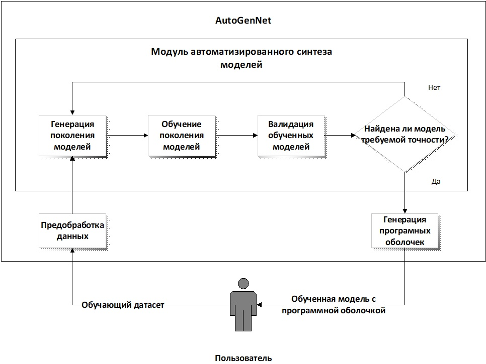

Рис. 2

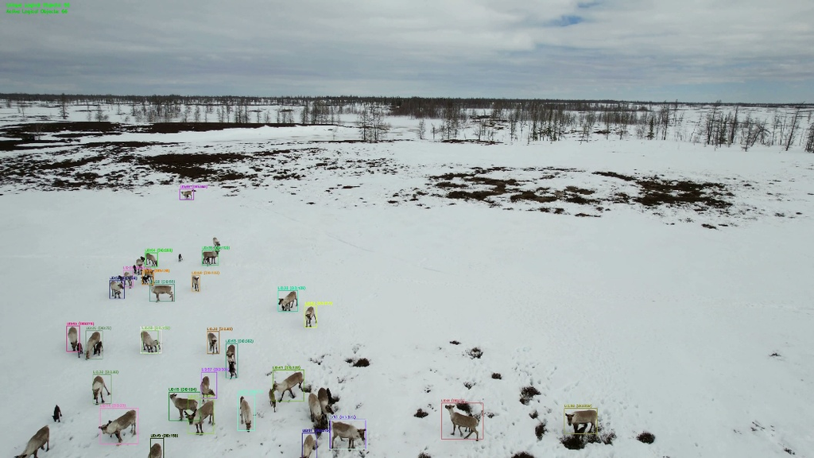

Рис.3

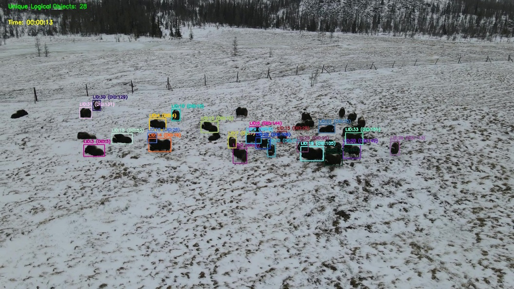

Рис. 4

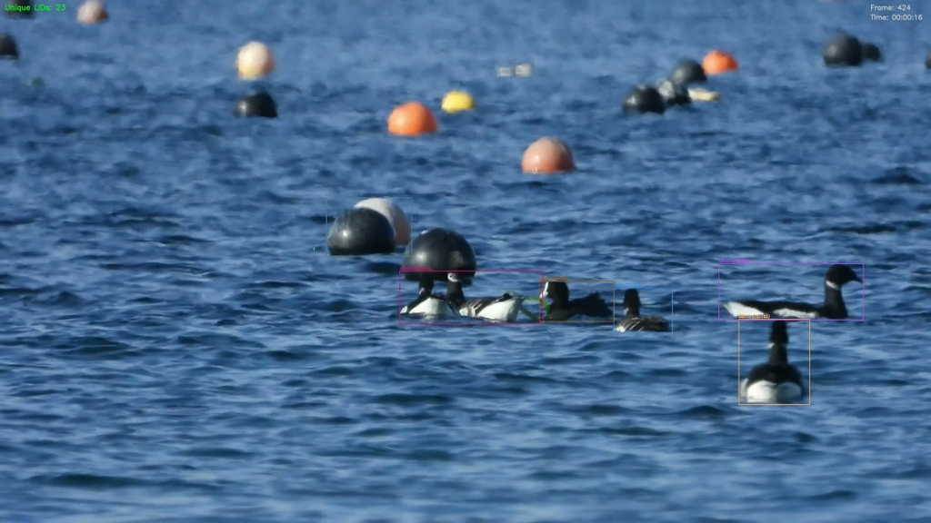

Информация об авторах

**Владислав Алексеевич Соболевский**

Телефон: +7-952-239-2144

e-mail: arguzd@yandex.ru

Санкт-Петербургский Федеральный исследовательский центр РАН

199178, Россия, Санкт-Петербург, 14 линия, д. 39

ID ORCID: https://orcid.org/0000 0001 7685 4991

**Владимир Валентинович Михайлов**

Телефон: +7-911-709-8665

e-mail: mwwcari@gmail.com

Санкт-Петербургский Федеральный исследовательский центр РАН

199178, Россия, Санкт-Петербург, 14 линия, д. 39

ID ORCID: https://orcid.org/0000-0001-6973-3526

**Федор Дмитриевич Гапоняко**

Телефон: 8(930)781-36-14

e-mail: fedoraug@gmail.com

Санкт-Петербургский Федеральный исследовательский центр РАН

199178, Россия, Санкт-Петербург, 14 линия, д. 39